# USCPIforecasting

This project is about forecasting US consumer price index. “The level of inflation is a serious impediment to economic recovery”. The best way to understand inflation is to use CPI.

```
View(CPI_U1)
CPIdata <-CPI_U1$`CPI`
summary(CPIdata)
length(CPIdata)
inds <- seq(as.Date("2011-01-01"), as.Date("2021-09-01"), by = "month")
CPIseries<-ts(CPIdata,start=c(2011, as.numeric(format(inds[1], "%j"))),frequency=12)
plot.ts(CPIseries,main="CPI over time", ylab="CPI value", col="blue")

kpss.test(CPIdata)
```

[figure not shown]

image

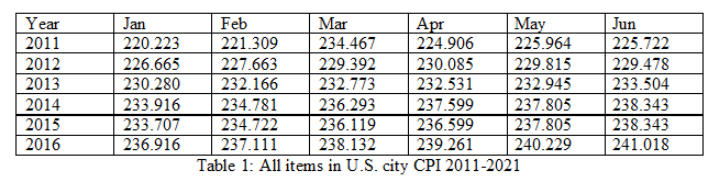

image

Dataset is used on U.S. Bureau of labor statistics,all items in U.S. city average, all urban consumers, not seasonally adjusted during 2011 January to 2021 October.

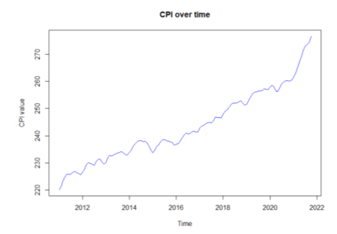

image

Graph1: Over time plot.

KPSS ADF test1:

__________ P value

KPSS test: 0.01

ADF test: 0.99

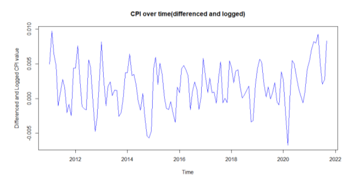

image

Graph2: Differences and Logged Consumer Price Index Plot

Much smooth than before.

KPSS ADF test2:

__________ P value

KPSS test: 0.1

ADF test: 0.01

Seasonal Test:

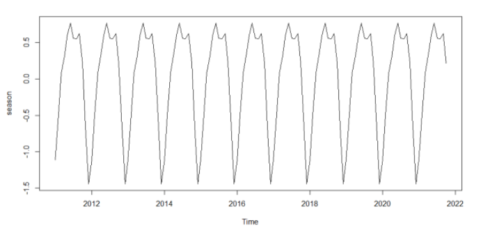

image

Graph3: Seasonal plot

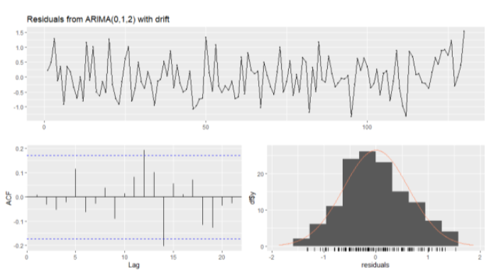

image

Graph4: Residuals for Consumer Price Index

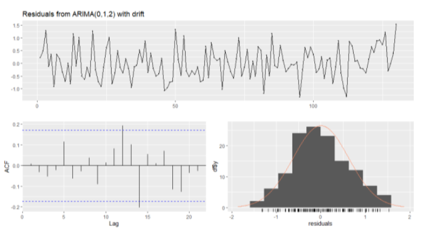

image

There is no obvious differece between two plots.

ACF PACF plot:

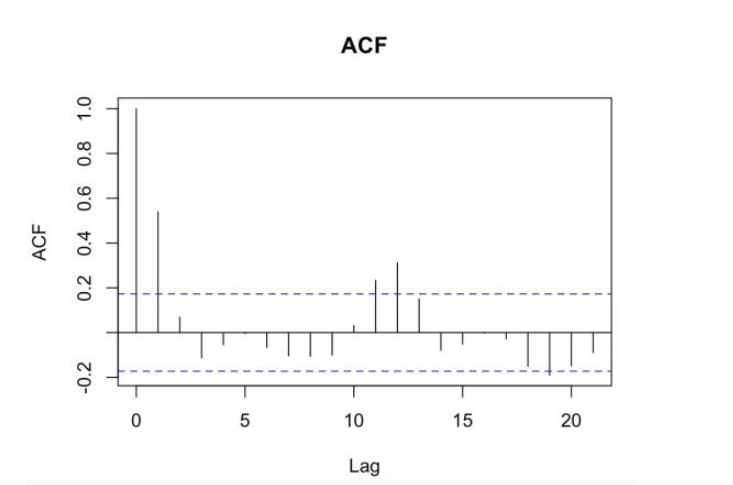

image

Graph6: Auto correlation function lag plot

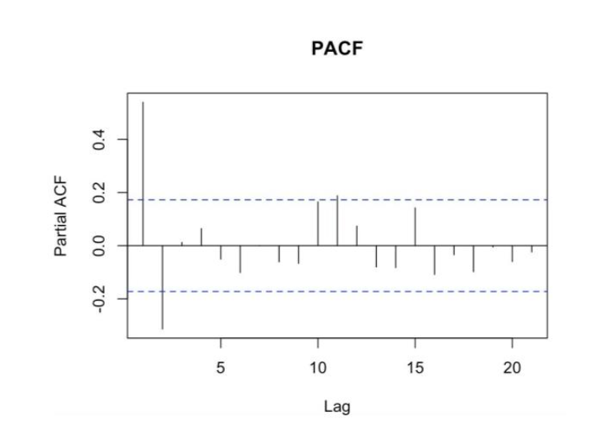

image

Graph7: Partial Auto-correlation plot

Lag ACF at 0,1,11,12. Lag PACF at 1,2,11

Find out best model by AIC BIC:

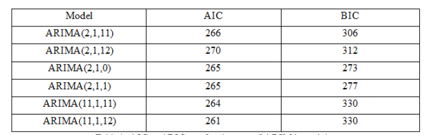

image

Table2: AIC and BIC test for the part of ARIMA models

AIC best:ARIMA(11,1,12) BIC best:ARIMA(2,1,0)

RMSE test: use predict data compare with original data.

_________________RMSE

ARIMA(11,1,12): 1.10775

ARIMA(2,1,0):2.09223

Prediction of CPI in 10 month :

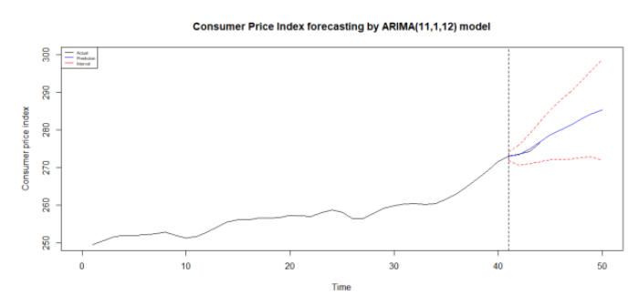

image

Graph8: ARIMA(11,1,12) Forecasting Result of Consumer Price Index